# Text Mining

Alun

12 March 2016

# Building Term Document Matrix

First load in the corpus which has been extracted from the html files, collected into documents (books) and cleaned through tokenisation, stop words removal, case folding and class equivalence. Also chapter titles were removed.

```
## <<DocumentTermMatrix (documents: 24, terms: 235468)>>
## Non-/sparse entries: 419035/5232197
## Sparsity           : 93%
## Maximal term length: 47
## Weighting          : term frequency (tf)
```

We now have a document term matrix with a lot of sparsity, a very large maximal term length and 24 documents. We can reduce a lot of this sparsity by remove documents which appear in only one document. And look at the most frequent terms.

```
## <<DocumentTermMatrix (documents: 24, terms: 37620)>>
## Non-/sparse entries: 221187/681693
## Sparsity           : 76%
## Maximal term length: 22
## Weighting          : term frequency (tf)
```

The sparsity has deceased and the maximum term length is something more reasonable. We can view the most frequent terms of each book to see which terms are highly weighted.

|  | 1 | 2 | 3 | 4 | 5 | 6 | 7 | 8 | 9 | 10 |
| --- | --- | --- | --- | --- | --- | --- | --- | --- | --- | --- |
| Geo Dictionary | name | citi | town | place | call | one | time | iii | mention | river |
| Tacitus Hist 3 | book | otho | time | soldier | legion | armi | vitellius | men | galba | see |
| Pelopennesian 2 | athenian | upon | now | lacedãmonian | also | time | war | one | enemi | made |
| Livy I | roman | emperor | empir | senat | rome | christian | see | everi | power | first |
| Decline & Fall 3 | con | time | tribun | roman | citi | enemi | peopl | one | war | common |
| Josephus 2 | king | also | upon | great | made | now | one | jew | god | came |
| Description of Greece | torn | lib | roman | year | might | two | thousand | emperor | hundr | first |
| Livy 3 | iii | son | call | citi | statu | god | place | one | page | templ |
| Decline & Fall 4 | roman | even | senat | time | rome | war | sulla | first | state | govern |
| Decline and Fall 2 | roman | consul | enemi | one | time | war | armi | order | samnit | men |
| Tacitus Annals 1 | athenian | upon | now | time | war | one | will | athen | citi | yet |
| Livy 5 | chap | roman | emperor | might | justinian | year | citi | first | thousand | law |
| Josphus 1 | julian | chap | emperor | roman | might | citi | war | provinc | empir | without |
| Decline & Fall 5 | peopl | consul | tribun | roman | citi | time | senat | upon | enemi | war |
| Tacitus Hist ? | time | tiberius | men | germanicus | roman | made | senat | legion | armi | rome |
| Decline & Fall 6 | upon | jew | citi | also | great | one | now | roman | men | made |
| Decline & Fall 1 | nero | book | see | time | life | emperor | rome | man | order | annal |
| History of Rome 3 | roman | order | consul | war | time | one | enemi | citi | two | armi |
| Pelopennesian 1 | king | god | upon | also | one | great | now | made | son | citi |
| Livy History | gold | silver | use | call | also | lib | kind | see | one | made |
| Joesphus 4 | lib | roman | justinian | might | year | emperor | two | tom | thousand | hundr |
| Tacitus Hist 4 | note | non | sed | qui | cum | per | quam | etc | word | galba |
| Pliny Nat. Hist | torn | year | two | first | hundr | greek | name | thousand | might | mahomet |
| Josephus 3 | upon | also | great | king | now | one | men | herod | made | jew |

We can see some themes such as the geographic dictionary having terms like river, citi, town and place. However also there are a lot of repeated and low impact terms like now, war, one, two, roman. So we weight the documents with inverse document frequency and normalise so that long books are evenly weighted vs. short books.

```
## <<DocumentTermMatrix (documents: 24, terms: 37620)>>
## Non-/sparse entries: 205203/697677
## Sparsity           : 77%
## Maximal term length: 22
## Weighting          : term frequency - inverse document frequency (normalized) (tf-idf)
```

```
##         herod  lacedãmonian         thefe     justinian           lib
##    0.02348538    0.02295514    0.01686666    0.01620840    0.01385286
##    belisarius           jew          fome      josephus constantinopl
##    0.01364605    0.01312184    0.01123468    0.01115044    0.01112206
```

Looking at the frequency table again…

|  | 1 | 2 | 3 | 4 | 5 | 6 | 7 | 8 | 9 | 10 |
| --- | --- | --- | --- | --- | --- | --- | --- | --- | --- | --- |
| Geo Dictionary | strab | steph | identifi | plin | tab | comp | cass | site | diod | herod |
| Tacitus Hist 3 | otho | vitellius | caecina | legio | galba | valen | section | vitellian | vinius | othonian |
| Pelopennesian 2 | lacedãmonian | syracusan | argiv | bå“otian | alcibiad | tissaphern | athenian | peloponnesian | gylippus | embassador |
| Livy I | cãsar | diocletian | prãtorian | christian | maximin | constantin | aurelian | maximian | probus | galerius |
| Decline & Fall 3 | thefe | fome | alfo | moft | fent | faid | afiembl | foon | whofe | ufe |
| Josephus 2 | herod | hyrcanus | jew | aristobulus | jonathan | judea | jerusalem | josephus | samaria | antipat |
| Description of Greece | justinian | belisarius | lib | mahomet | constantinopl | caliph | saracen | heraclius | mecca | arab |
| Livy 3 | fay | statuari | theban | âââ | lacedãmonian | ââ | bå“otian | proclus | delpho | dãmon |
| Decline & Fall 4 | sulla | burgess | gaius | gracchus | marius | carbo | epoch | hellen | jugurtha | financi |
| Decline and Fall 2 | samnit | etrurian | samnium | honor | decius | consul | intir | pretor | favor | hannib |
| Tacitus Annals 1 | lacedaemonian | corcyrean | peloponnesian | brasida | athenian | hath | plataean | thucydid | megarean | boeotian |
| Livy 5 | belisarius | justinian | constantinopl | heraclius | lombard | chosro | chap | gothic | goth | constantin |
| Josphus 1 | constantius | constantin | theodosius | valentinian | gratian | valen | jovian | julian | libanius | ammianus |
| Decline & Fall 5 | volsci | veii | virginius | tarquin | decemvir | quinctius | icilius | etrurian | consul | appius |
| Tacitus Hist ? | germanicus | arminius | drusus | csecina | piso | cheruscan | livia | plancina | segest | libo |
| Decline & Fall 6 | josephus | jew | herod | jerusalem | judea | idumean | hath | ananus | simon | jesus |
| Decline & Fall 1 | appen | nero | corbulo | silanus | thrasea | suet | lepida | tirid | julia | vologes |
| History of Rome 3 | pretor | masinissa | syphax | hasdrub | attalus | hannib | carthaginian | laelius | intir | mago |
| Pelopennesian 1 | david | saul | herod | josephus | hyrcanus | jonathan | mose | highpriest | hebrew | israelit |
| Livy History | lbs | minium | valpi | lib | copper | oxid | solder | lond | foss | dioscorid |
| Joesphus 4 | justinian | belisarius | lib | gothic | goth | procopius | constantinopl | chosro | heraclius | theodor |
| Tacitus Hist 4 | etc | nec | rup | vitellio | nequ | quam | ann | exercitus | dod | othoni |
| Pliny Nat. Hist | mahomet | caliph | saracen | mecca | arab | moslem | medina | bibliot | patriarch | constantinopl |
| Josephus 3 | herod | antipat | jew | tiberia | pherora | archelaus | aristobulus | judea | hyrcanus | highpriest |

We can see now using term frequency - inverse document frequency (tf-idf) that the highest weighted terms are now primarily names. herod, justinian etc. This is suggestive that the clustering later will be about the people and places (names) associated with those books.

Finally we calculate a distance measure. In this case we use cosine similarity.

Plot results

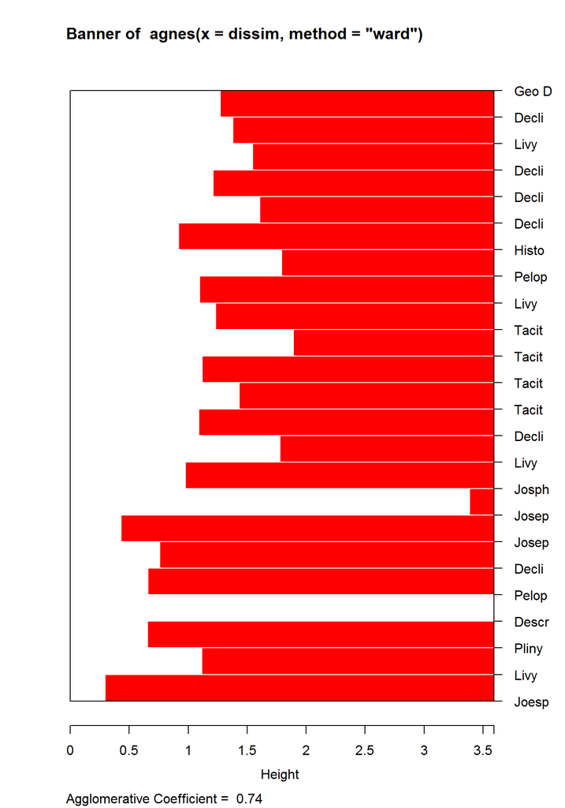

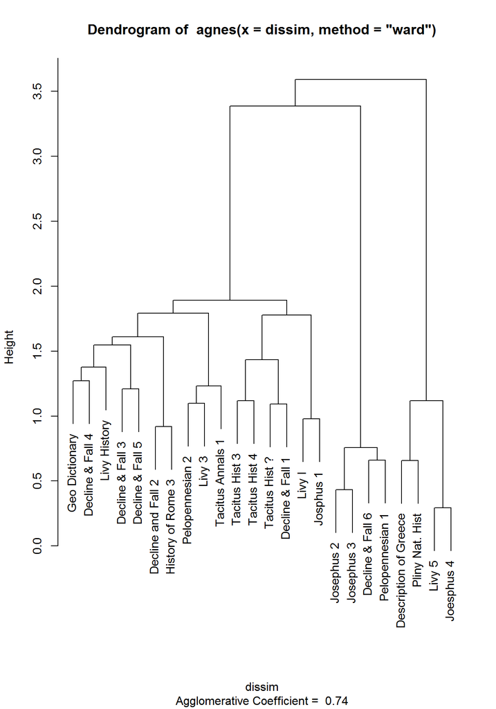

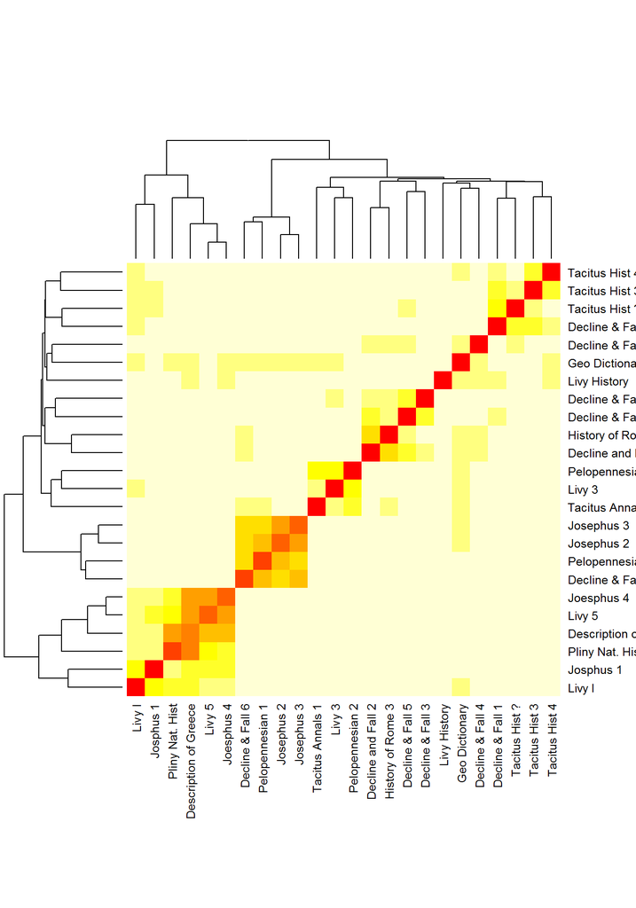

Spherical k means clustering works on cosine similarity as well.

```
## Iteration: 1 *** value: 6.98077
```

```
## Iteration: 2 *** value: 6.98077
```

```
##      Decline & Fall 3      Decline & Fall 5        Geo Dictionary
##                     1                     1                     2
##      Decline & Fall 4    Decline and Fall 2     History of Rome 3
##                     2                     2                     2
##        Tacitus Hist ?      Decline & Fall 1        Tacitus Hist 3
##                     3                     3                     4
##        Tacitus Hist 4 Description of Greece                Livy 5
##                     4                     5                     5
##            Joesphus 4       Pliny Nat. Hist       Pelopennesian 2
##                     5                     5                     6
##            Josephus 2                Livy 3      Tacitus Annals 1
##                     6                     6                     6
##      Decline & Fall 6       Pelopennesian 1            Josephus 3
##                     6                     6                     6
##                Livy I             Josphus 1          Livy History
##                     7                     7                     8
```

```
## Silhouette of 24 units in 8 clusters from silhouette.skmeans(x = clust_sk) :
##  Cluster sizes and average silhouette widths:
##          2          4          2          2          4          7
## 0.10124133 0.05458723 0.13739062 0.11819122 0.53809545 0.17272309
##          2          1
## 0.14003568        Inf
## Individual silhouette widths:
##    Min. 1st Qu.  Median    Mean 3rd Qu.    Max.
##       0       0       0     Inf       0     Inf
```